# R Learning Guide

Mike Bader

February 2018

# Welcome to R!

You are embarking on an exciting adventure to learn extremely powerful software that you can download **for free**.

## What is R?

Let’s start by describing this powerful tool to start. R is both:

- A statistical computing software
- A full-fledged programming language

If you have learned other statistical software, you might wonder why you would want to learn another. Especially because many find that R has a steeper learning curve than these software programs.

## Difference from Other Statistical Software

Other statistical software like Stata, SPSS, and SAS do one thing: they take a table (spreadsheet) of data and statistical commands to analyze that data.

R can do this, too. But R can do many more things because R is an entire programming language. It has many different types of data that you can use. You can put in a table (called a “data frame” in R-speak), but you have lots of other types of data that you can use. It offers much more flexibility than other statistical software.

BUT, that flexibility comes at the cost of simplicity.

## Why R?

So why make you learn something that’s harder than what you have already learned?

- R is open source (free as in speech), which means that many different people can help extend the language to do common tasks or specialized analysis
- R is the future of statistical software; employers will be increasingly moving to R
- Lest we forget, let us remember that R is **free** (as in beer); you can use it on any computer and with any employer. Many of you will be working for employers that might not have large budgets; learning free software means that you will always be able to use it.

  | SAS[^1] | $9,720.00 | + Windows only |
  | --- | --- | --- |
  | SPSS[^2] | $99.00/month | + $237.00/month add-ons |
  | Stata[^3] | $1,695.00 | + $300 for large datasets |
  | R | $0.00 |  |

We’re talking about a substantial amount of money!

## Getting R

### Download R

I hope that I have convinced you to at least try R at this point. That means you will need to get this amazing, powerful, and cost-effective software. You will need to download R. To do so Go to https://www.r-project.org/ and look for the link that says “Download.” After you do that, you will be sent to a list of mirrors (servers that distribute R so that no single server gets overloaded). Find the United States and download one from that lists (I use the [National Institute for Computational Sciences in Oak Ridge, TN](https://mirrors.nics.utk.edu/cran/)).

### RStudio

If you open up R after downloading it, you will see that it gives you *nothing* except a command line to type in commands to be run. This is not ideal and would make R *really* difficult if that was the only way with which you could interact with R.

That is where RStudio comes in. RStudio is an *Integrated Development Environment (IDE)* for R. That means that RStudio gives you a window into R–basically it acts as a gopher between you and R.

In acting as a gopher, it provides a nice *graphical user interface (GUI)* that makes R a lot easier to use.

There are four different windows in RStudio that you will use:

**Source (ctrl-1)**

This is where you keep your scripts where you do your analysis. These are the same as `.do` files in Stata.

**Console (ctrl-2)**

This is where you can type commands directly to tell R what to do. You should use this sparingly because only entering commands in the console makes it difficult to reproduce what you have done. My advice: work in the source window, then copy/paste into the console (or source the command directly by pressing ‘ctrl-Enter’—we’ll get to that)

**Environment**

This window shows you all of the objects that are currently available in R. Remember how I told you that R can hold different types of data? This is where you will find all of them. A second tab in that window contains your history, which contains the list of commands that you have entered into the console.

**Viewer**

This window is where you will view help files and plots that you make (you can view a whole bunch of other stuff down there, but those are for more advanced applications).

To get RStudio, you will go to https://www.rstudio.com/ and then find the link for RStudio and download. This software is also free.

### Getting Help

As you go on this adventure, you will likely need help along the way. There are a couple of great resources on the web to help you learn just about everything that you would like to do.

**[Stack Overflow](https://stackoverflow.com/questions/tagged/r)**

provides user-generated answers to questions posed in forums. Good answers tend to filter to the top of the list based on an ingenuous ranking system of votes and points.

**[Rseek](https://rseek.org/)**

gives Google-like search functionality to find R-related material.

**[R-bloggers](https://www.r-bloggers.com/)**

is a blog with posts that cover tutorials and code for basic to advanced material

# Variables and Data

## What is a Variable?

In R, *variables* differ from variables in other statistics programs. In Stata or SPSS, variables represent columns in a dataset. In R, variables can take on many different forms: vectors (a row of numbers or letters), datasets (called “dataframes”), scalars (a single number or letter), among many others ([here](https://www.statmethods.net/input/datatypes.html) is a list of different R objects).

### Numeric

We will “assign” variables in R using the operator `<-`. If we want to create a variable containing the number of states in the United States (50) to a variable named `N_states` for [N]umber of [states][^4] we might write:

```r
N_states <- 50
```

Any time we write `N_states`, R will read that as “50”. So if I type `N_states * 2` into the console, I will get:

```r
N_states * 2
```

```
## [1] 100
```

### Strings

We can also assign strings, or in R-speak “characters”, to variables. I can create a variable called `my_state` that contains the string `Maryland` in it. We can then do things with that variable like make parts of sentences.

```r
my_state <- "Maryland"
paste("I live in",my_state)
```

```
## [1] "I live in Maryland"
```

Here we have used the `paste()` *function* to glue the string `"I live in"` to the string stored in `my_state`, which R reads as `"Maryland"`. If you wanted to change the value in your state, you would only need to change the value of `my_state`, enclosed in quotes, to represent your state. As a matter of fact, you don’t even need to enter a state into the variable `my_state`, you can enter any value you want. For example:

```r
my_state <- "a galaxy far, far away"
paste("I live in",my_state)
```

```
## [1] "I live in a galaxy far, far away"
```

This works because R doesn’t care what string `my_state` actually contains. Now that I have entered `"a galaxy far, far away"`, R will just look for the name `my_state` and substitute the value stored in that variable. You should note that *variable names are for humans* to make sense of what’s contained within them. R does not care what you name a variable, it just cares what you assign to the variable of that name.

**Watch out:** One common error is to forget to enclose words in quotes that you want to use as strings. R will “throw” an error if you type the following:

```r
my_state <- Maryland
```

```
## Error in eval(expr, envir, enclos): object 'Maryland' not found
```

You will see that the console tells you “Error: object ‘Maryland’ not found”. That means that R looked for a variable (that’s the object its referring to) called `Maryland`, but it couldn’t find one. In order for the string of letter M-a-r-y-l-a-n-d to be read as the string “Maryland”, you need to enclose it in quotes.

### Vectors

Vectors are another useful type of object in R. We create these by “combining” elements, separated by commas, into a single object. One of the most annoying aspects of R is that you must use a function, `combine()` to create vectors. Fortunately, because we use that function so often, it has an abbreviation: `c()`.[^5] Let’s say that I want to create a vector containing the states in which I have lived. I would write:

```r
my_states <- c("Colorado","Washington","Maryland","Texas",
               "Michigan","New York","Pennsylvania")
```

Anytime I type `my_states`, it will return the vector containing this set of string values. With a “for loop” we could do the following (don’t worry about following the for-loop, just see that I can operate on each element of the vector):

```r
for(state in my_states) {
    print(paste("I lived in",state))
}
```

```
## [1] "I lived in Colorado"
## [1] "I lived in Washington"
## [1] "I lived in Maryland"
## [1] "I lived in Texas"
## [1] "I lived in Michigan"
## [1] "I lived in New York"
## [1] "I lived in Pennsylvania"
```

Note that when I initialized the variable `my_states`, I split the code across two lines. Normally R would execute each line as a command. R, however, allows you to split lines inside of parentheses and it won’t attempt to execute the command until it finds the closing parens. This allows you to keep your code in a reasonable width, which improves legibility (generally try to keep each line under 80 characters in width).

## Open a Dataset

None of this provides much excitement. After all, if you are reading this tutorial, you likely want to analyze data. In order to analyze data, we need to open a dataset to analyze.

**Data frames.** Remember that R stores every object with a variable name: this includes datasets! As I mentioned above, R names datasets “data frames”. That means that we will load the data into a variable and then operate on that variable to do things with the data. This differs substantially from Stata or SPSS where you will load a single data set and then the software will assume that you are refering to that dataset when you send commands to the program.

For this example, we will use data from the 2016 DC Area Survey (DCAS2016), a survey of residents in multiracial neighborhoods in Washington, DC and the surrounding jurisdictions. The data are available at https://hg.mikebader.net/private/dcas2016/raw-file/tip/Dataset/DCAS_2016_weighted.csv (email me to get the username and password if you would like to download the data).

The file contains the data in *comma separated values (csv)* format. The first row contains “variable” (in the sense of data variables, not in the R sense) names separated by commas. Each of the following rows contains the responses for a single respondent with each reponse separated by a comma.

Comma separated values can always be read, which gives them a huge advantage over files saved in a format that cannot be read. It’s like saving a text file on your computer versus a Microsoft Word document. It seems fine because of Word’s ubiquity. But I’m old enough to remember when WordPerfect was the word processor that everyone used. Good luck getting one of those files to open now.

I digress. We have two options for data that are available on the web: we can download the data and open the file from our machine or we can open the data directly from the internet. My advice would be this: if you a dataset will not change, then download a copy so that you can use it at any time. If a dataset will change, for example by getting new data appended as they become available, it’s probably better to open the data from the internet.

### Loading data from a file on your computer

You will open data that you have saved on your own machine (also known as loading from a ‘local file’). To be able to open the data, you will have to tell R where you have stored it on your computer. To do this, you will need to know a) the directory in which you stored it and b) the file name. Every operating system stores files into different directories. You probably know these as folders when you go to “My Computer” on a PC or “Macintosh HD” on a Mac (if you use Linux, I will assume that you know all of this and you can probably tell me how I’ve gotten this wrong). The folders just provide a visual representation of directories.

```r
dcas <- read.csv("~/work/Data/DCAS/dcas2016/Dataset/DCAS_2016_weighted.csv")
```

Let’s break what we did here into its parts:

- `dcas`  
  This is the object that holds the dataset that we read from the file. If we ever want to refer to the dataset, we would need to reference its name, `dcas`, first. One of the really cool things about R is that you can have multiple datasets open at the same time; that means, however, that you have to refer to the dataset that you want to use by its name.
- `<-`  
  Just as with the variables above, this means “assign” the contents of the file to the variable name `dcas`.
- `read.csv()`  
  This is the *function*. You can tell that it is a function because it has parentheses after it. Inside the parentheses are different *arguments* that you pass to the function. A function will then take those options and do something with them.
- `"~/work/Data/DCAS/dcas2016/Dataset/DCAS_2016_weighted.csv"`  
  is a file that holds the data that we want. Notice that we must put the file name in quotations. Otherwise R would look for an object of the name `~/work/Data/DCAS/dcas2016/Dataset/DCAS_2016_weighted.csv` (which would fail miserably).

R did not complain to us, so that’s a good sign. But, the data might not have loaded correctly, so I always like to check. You can do this in two ways if you are using RStudio. The first, and my preferred way, to check the data is to use the `View()` function, which will show you the contents of the object in the source window.

```r
View(dcas)
```

You can see the result of the `View(dcas)` command in the source pane (top left pane) in the image below. The data appear to be set up correctly. The data’s variables are listed across the top, the actual values in the cells. Everything looks good!

[figure not shown]

The `head()` function provides another way to check the data. This works whether or not you are using RStudio. The `head()` function takes one required argument, the data frame object. By default it will show you the first six rows of data. You can add an extra argument, however, to tell it how many rows you want reported.

Although most R tutorials and resources tell you to use `head()`, I don’t find it useful because it prints so much data, it can be very difficult to read. Below, I will show you what the data look like including only the first 15 columns of the data. If you would like to see the full results in all of their ugliness, you can type `head(dcas)` rather than what I have here. Just remember, I warned you!

```r
head(dcas[,c(1:15)])
```

```
##   pk study studycase weight   q1 q2 q3 q4                  q5
## 1  1 O1087     10001 0.3054  Own  0  2 13      Very satisfied
## 2  2 O1087     10002 3.8336 Rent  4  3 16      Very satisfied
## 3  3 O1087     10003 1.1124  Own  1  2 16      Very satisfied
## 4  4 O1087     10004 0.5104  Own  1  1  8      Very satisfied
## 5  5 O1087     10005 0.2154  Own  0  0 12 Extremely satisfied
## 6  6 O1087     10006 0.2229  Own  0  1 12      Very satisfied
##                            q6              q7              q8
## 1 A much better place to live   1 to 4 blocks   Very unlikely
## 2 A much better place to live   5 to 9 blocks   Very unlikely
## 3 A much better place to live 10 to 25 blocks   Very unlikely
## 4 A much better place to live   5 to 9 blocks Somewhat likely
## 5 A much better place to live   5 to 9 blocks     Very likely
## 6 A much better place to live   1 to 4 blocks   Very unlikely
##                                       q9 q10_1 q10_2
## 1     Become a much better place to live  Some A few
## 2  Become a somewhat worse place to live A few  None
## 3                  Stayed about the same  None  None
## 4                  Stayed about the same  Most  None
## 5     Become a much better place to live A few A few
## 6 Become a somewhat better place to live  None  None
```

### Loading Data from the Internet

The other option you have to read data into R is to read it directly from the internet. In this case, you will pass the URL where the data are stored to the `read.csv()` file rather than a file in a local directory. As I mentioned above, this feature might be especially good for data that are updated regularly.

Zillow provides one such source of data. On their [research data page](https://www.zillow.com/research/data/), Zillow provides a number of time series datasets that they update either every quarter or every month. One could use these updated data to track trends and automatically get the most recent results available by downloading from the web.

The data that I will use for this example uses Zillow’s proprietary [Home Value Index (ZHVI)](https://wp.zillowstatic.com/3/ZHVI-InfoSheet-04ed2b.pdf) because it contains estimates over many years for most US metropolitan areas. The file is located at: http://files.zillowstatic.com/research/public/Metro/Metro_Zhvi_AllHomes.csv.

Therefore, we will download the data by passing that URL to the `read.csv()` function rather than a file on our own computer (remember the put the URL in quotes).

```r
zillow <- read.csv("http://files.zillowstatic.com/research/public/Metro/Metro_Zhvi_AllHomes.csv")
```

Now it would be wise to inspect the data, either by using `View(zillow)` in RStudio or `head(zillow)`.[^6]

## Review: Variables and Data

- R provides a versatile, powerful set of tools for free (as in beer) with a large and stable user base that can contribute to the development (free as in speech)
- R can (and does) store all types of objects into variables, including numeric, strings, and vectors
- You must load data into an object and can do so by either downloading data and loading it from your local machine or from the internet.

# Descriptive Statistics in R

## What are Descriptive Statistics?

They are *univariate* statistics that describe the characteristics of respondents in the study. Now remember, descriptive statistics are a *model*: they abstract all of our data into a single number.

We are going to find the mean and the standard deviation of data from the DCAS2016

## Calculating Descriptive Statistics in R

You should have, from last time, the DCAS2016 data already loaded. I am going to assume that you have that loaded into a variable called `dcas`.

Now, remember that the variable `dcas` contains a spreadsheet, or a matrix. R will be looking for you to define the elements of the spreadsheet based on *rows* and *columns*.

*Columns* In a dataframe, we can refer to a column of data by using the `$` operator. If we write

```
dcas$q4
```

that means, give me all of the rows of the spreadsheet `dcas`, but only the values in column `q4`. What you will get will be a *vector*. A vector is a series of values (think of a list, but lists actually have a different meaning in R.)

Now, it turns out that `q4` corresponds to Question 4 from the DCAS2016 (logical, right?), which reads:

> **4. How many years have you lived in your current neighborhood?** *Answer 0 if less than 1 year.*  
> __________ *years (write in number of years)*

If we have done everything right, and we type the following into our console in RStudio, we should get a list of integers corresponding to the number of years respondents have lived in their current neighborhood:

```r
dcas$q4
```

```
##    [1] 13 16 16  8 12 12 24 35 12 12 11 19  5  8 11  3 10  1 50  2 22  7 35
##   [24] 38 16 31 29 26 33  3 52 26  1  2 60 50 22 14 20 11 13 10 13 25  3  4
##   [47] 32 20 17  3 20  1 37 27 34 17  2 15 15  7 26  3 22 40  2 10  4 26 17
##   [70] 11 14 41 53 97  5 26 19  3  5 97 60 32  3  3 14 27 37 49  2 30 31 29
##   [93] 18  2 11  3  3 38  4 15  7 20  4 20 56 10 20 10  0 36  1 33  1 10  7
##  [116] 13 15  2 24  9 12 28 11 14  8  2 30  2 11  4  4  0 45 17 40 14 43 13
##  [139]  0  3  5 32 35  7 41 12 20  3 27  8 45 23  3  6  0 26 25 29 25  2 18
##  [162] 18 12 18 32  1 22  7 34 16 50 12 17  2 13 25 14 36 26  5 12  2  3  3
##  [185]  0  3  6  2 17 49 22 20  4  3 23 10  8 10  7 20 50  8 26 20 15  0  8
##  [208] 50 20 12 40  4 35 10 13 22 32  4  0  0  7  2  2  4 18  0 24  8 17 28
##  [231]  8  3 20 15  4  3 14 15  2 28  3 22 50  1 14  2  2  2 40 14 18 97  2
##  [254] 15 30  3 15  9  3 18 26 23 20 14  2  0 30  1 18  6  6 11 25 20  9 10
##  [277] 27 11 40 97 13  0 20  2  5 66 27 12 25  6  3  3 12 24  6 20  2 18 28
##  [300]  0 45 20  3 27  1  0 52 31 30 42  8 35  2 35  2 12 12 15 11  1 32 46
##  [323]  3  6 10  2 32 31  1 17  6  3 15  3  8 19 20 11 15 13  9 14  4 25 51
```

[output cut: 39 more lines]

A couple of notes:

Now that does not seem like a way to report anything – even R is like, um$\ldots$ this is too long for me. A better number would be the *mean*. We want to know the average number of years residents have lived in their neighborhood.

To get that, we would put the following in our code:

```r
mean(dcas$q4)
```

```
## [1] 15.95499
```

- `mean()` is a function that says give me the mean of all of the numbers inside my parentheses, in this case the vector `dcas$q4`.
- The response starts with `[1]`, which tells us that the first element of the responses on that line starts with the first element. It’s not particularly helpful in this case because there is only one element, which is$\ldots$
- `15.95499`, the average number of years that respondents lived in their neighborhoods

Now, unlike Stata or SPSS, R makes it very easy to save that value into another value that we can then use. We just need to assign it to a variable name, like so:

```r
mean_years <- mean(dcas$q4)
```

Uh oh! We didn’t get any output!!!

That’s okay, we actually shouldn’t get any output. Rather than telling *us* what the value is, R gives that value to the variable `mean_years`. But, if we type `mean_years` into our file, then we get:

```r
mean_years
```

```
## [1] 15.95499
```

Okay, so we have the average number of years respondents have lived in their neighborhood stored in the variable `mean_years`. But, we probably don’t want to report the value to five decimal places; after all, we were only precise to the number of years. It probably makes sense to round the value to one decimal place. To do that, we would use the function `round()`:

```r
round(mean_years,1)
```

```
## [1] 16
```

When we do, it turns out that it equals 16 which is actually 16.0, but if the last digit equals zero, R does not report it.

We could do this all in one step if we wanted. Remember that `mean_years` equals the value of `mean(dcas$q4)`, so figuring out the rounded value would be: `round(mean(dcas$q4))`:

```r
round(mean(dcas$q4),1)
```

```
## [1] 16
```

And we could save that final value into the variable `mean_years`:

```r
mean_years <- round(mean(dcas$q4),1)
mean_years
```

```
## [1] 16
```

Now let’s find the standard deviation. The function for standard deviation in R is `sd()`. To get the value to one decimal place we would write:

```r
sd_years <- round(sd(dcas$q4),1)
sd_years
```

```
## [1] 16.1
```

We have a mean of 16 and a standard deviation of 16. Seems to me that the variable can’t be normally distributed. Let’s look at a histogram to see:

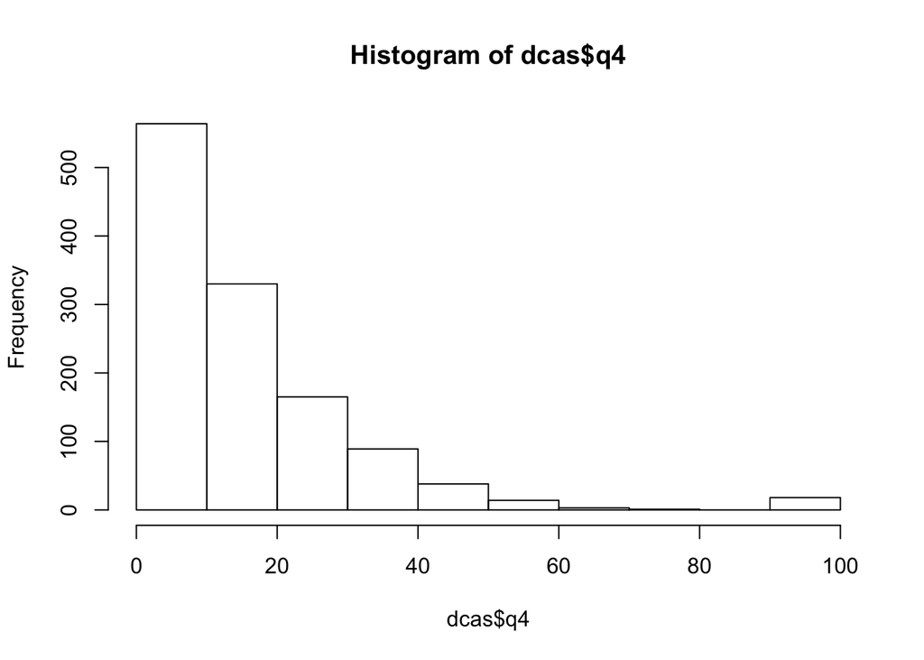

```r
hist(dcas$q4)
```

Sure enough, it’s not. But we’ll worry about that later.

## Calculating Descriptive Statistics of Categorical Variables

This process works well for continuous variables, but for categorical variables we want to report the percentage or proportion of the respondents who fall in each category. To do that, we will use the `table()` command (which is like `tab` in Stata).

Let’s look at Question 1 from the DCAS2016:

> **1. Do you rent your home, own it, or do you have some other arrangement?**

> ____ Rent

> ____ Own

> ____ Some other arrangement

If we tried to calculate the mean of Question 1, let’s see what we would get:

```r
mean(dcas$q1)
```

```
## Warning in mean.default(dcas$q1): argument is not numeric or logical:
## returning NA
```

```
## [1] NA
```

As Scooby Doo would say, Ruh Roh!!! Let’s parse what R returned here. On the first line, R complained:

```
Warning in mean.default(dcas$q1): argument is not numeric or logical:
```

In the first part of the statement (before the colon) R is telling us that it is giving us a warning, which means that the program will not stop running but something might be wrong. In the second part of the statement, it is telling us that the data we passed, `dcas$q1` does not contain either numeric data or logical (True/False) data. That makes sense, this is a categorical variable. We have three response options: Rent, Own, Some other arrangement. It doesn’t make sense to take the mean of that categorical value.

In the second line, R tells us:

```
returning NA
```

Okay, this is easier. In R, the value `NA` means that the value does not exist. Together, in these two lines R is telling us:

> I’m warning you that you gave me a value that doesn’t make sense with this function (you should have given me either numbers or a list of Trues and Falses), so I’m going to give you back a placeholder that represents nothing.

What we want to do instead is to list the possible options using the `table()` function, as I mentioned earlier. Let’s see what we get when we do that:

```r
table(dcas$q1)
```

```
##
##              No Answer                    Own                   Rent
##                      9                    859                    318
## Some other arrangement
##                     36
```

This looks better. We find out that 859 respondents own their homes, 318 rent, 36 have some other arrangement, and 9 gave no answer.[^7]

Okay, that’s helpful, but not exactly what we want. We want to know the *proportion* of respondents who gave each value. We calcluate the proportion giving response *r* as:

$$P(r) = \frac{N_r}{N}$$

The proportion (or probability) that respondent answered Question 1 with response category $r$ equals the number of respondents who answered the question with category $r$ divided by the number of respondents, *N*. To make this more concrete:
$$P(own)=\frac{N_{own}}{N}=\frac{859}{(859+318+36+9)}\approx0.70$$
.

We could go through and do all of those calculations, or we can have R do it for us. I would prefer to let R do it for me. To do that, we will need to figure out how many respondents there are. The function `nrow()` tells us how many rows there are in a dataframe.

```r
N <- nrow(dcas)
prop_own <- table(dcas$q1)/N
prop_own
```

```
##
##              No Answer                    Own                   Rent
##            0.007364975            0.702945990            0.260229133
## Some other arrangement
##            0.029459902
```

What we just did was to tell R to divide each cell in the table created by `table(dcas$q1)` by the number of respondents, `N` (which equals 1222). The table we got was better, but still not great given the long decimals. Let’s round them off and replace what’s stored in `prop_own` with the rounded values. Since we have proportions, it would make sense to round to two or three decimal places:

```r
prop_own <- round(prop_own,2)
prop_own
```

```
##
##              No Answer                    Own                   Rent
##                   0.01                   0.70                   0.26
## Some other arrangement
##                   0.03
```

Now you could report the descriptive statistics for the categorical variables as the proportion of respondents who reported being in each category.

[^1]: For SAS Analytics Pro https://www.sas.com/en_us/software/analytics-pro.html; January 20, 2018
[^2]: https://www.ibm.com/products/spss-statistics/pricing; January 20, 2018
[^3]: Stata 15 government & nonprofit pricing https://www.stata.com/order/new/gov/single-user-licenses/dl/; January 20, 2018
[^4]: R reads periods `.` as spaces, like underscores. Those who code in Python will likely find this convention frustrating since Python uses the dot notation to identify methods or properties of an object’s instance. In my own coding, I now try to use underscores rather than dots so that I do not continue to confuse myself, even though dots are conventional in R.
[^5]: For those unfamiliar with other programming languages, this might not seem weird. For those of us who program in other languages, for example Python, we get used to typing `my_list = [1,2,3,4]`. Creating a similar object in R requires that we type `my_list = c(1,2,3,4)`. I usually introduce errors in my code when I switch back to R from another language because I try to type `my_list = (1,2,3,4)` and end up with an error.
[^6]: If you inspect it closely, you will see that the first row contains data for the entire US rather than an individual metropolitan area. If you wanted to use these data to compare metropolitan areas, then you would want to remove that row before any analysis. We will discuss how to do that later in this Guide.
[^7]: Technically these should be represented by `NA` since they don’t have an answer, but we will save that for a later date.